# Tutorial: Stochastic Simulation

This tutorial shows the basics of running a simulation driven by noise (ie, using a stochastic integration scheme). It discusses the choices around specifying the driving stochastic process, and then performs a simple simulation to show the results.

Here we'll use a region level simulation, but the considerations for surface simulations are the same.

We'll start as usual by importing a bunch of tools:

```python
from tvb.simulator.lab import *
```

```
2014-05-04 00:04:46,628 - INFO - tvb.simulator.common - Additive(ntau, random_stream, nsig): initing...
2014-05-04 00:05:27,160 - INFO - tvb.simulator.common - Generic2dOscillator(**kwargs): initing...
2014-05-04 00:05:27,288 - INFO - tvb.simulator.common - HeunDeterministic(dt): initing...
2014-05-04 00:05:27,291 - INFO - tvb.simulator.common - TemporalAverage(period, variables_of_interest): initing...
Couldn't import dot_parser, loading of dot files will not be possible.
```

and then initialising our standard region level simulation: with a Generic2dOscillator model; the default 74 region Connectivity, with a conduction speed set to 4ms$^{-1}$; a Linear coupling function with a scaling factor of 0.0152; and two Monitors, one raw, ie returning all the simulated data, and the other a TemporalAverage, which we'll set to record at 2000Hz and by default only returns the state-variables specified in the Model's variables_of_interest attribute.

```python
#Initialise a Model, Coupling, and Connectivity.
oscillator = models.Generic2dOscillator()
white_matter = connectivity.Connectivity()
white_matter.speed = numpy.array([4.0])

white_matter_coupling = coupling.Linear(a=0.0152)

#Initialise some Monitors with period in physical time
mon_raw = monitors.Raw()
mon_tav = monitors.TemporalAverage(period=2**-1)

#Bundle them
what_to_watch = (mon_raw, mon_tav)
```

```
2014-05-04 00:05:38,261 - INFO - tvb.simulator.common - Generic2dOscillator(**kwargs): initing...
2014-05-04 00:05:38,282 - INFO - tvb.simulator.common - Raw(period, variables_of_interest): initing...
2014-05-04 00:05:38,283 - INFO - tvb.simulator.common - TemporalAverage(period, variables_of_interest): initing...
```

## A Stochastic (Noisy) Integration Scheme

Noise enters through the integration scheme, here we'll define a simple constant level of noise that enters all nodes and all state variables, however, the noise is configurable on a per node and per state variable level, and as such the noise can be reconfigured to, for example, only enter appropriate state variables of certain thalamic nodes, thus emulating a very crude model of brain stem input to the brain.

We can choose between Additive and Multiplicative Noise functions when defining the way noise enters our simulation. In the case of Multiplicative Noise the function depends on the state of the system.

The Noise functions are fed by a NoiseStream, that is, a random process generated by a pseudo-random number generator. The random processes used have Gaussian amplitude and can potentially be given a temporal correlation. The random process is defined using two parameters plus the state of the NoiseStream. The two parameters are: nsig, defining the standard deviation of the noise amplitude; and ntau which defines the correlation time of the noise source, with ntau = 0 corresponding to white noise and any value greater than zero producing coloured noise. The state of the NoiseStream can be specified using a random seed, which is just a number, by default the random seed is 42.

Here, we'll specify a small amplitude white noise and pass it into our stochastic integrator. As a general rule of thumb, the noise amplitude, when being applied to all nodes and all state-variables, should be much less than 1% of the expected state-variable range if you don't want the noise to dominate the intrinsic dynamics of the system.

```python
#Initialise an Integrator
hiss = noise.Additive(nsig = numpy.array([2**-10,]))
heunint = integrators.HeunStochastic(dt=2**-4, noise=hiss)
```

```
2014-05-04 00:05:38,291 - INFO - tvb.simulator.common - Additive(ntau, random_stream, nsig): initing...
2014-05-04 00:05:38,300 - INFO - tvb.simulator.common - HeunStochastic(dt, noise): initing...
2014-05-04 00:05:38,304 - INFO - tvb.simulator.common - HeunStochastic(dt, noise): initing...
```

We can get a quick idea of what the noise amplitude that we've set looks like in comparison to our chosen Model using the PhasePlaneInteractive plotting tool. For more details about using PhasePlaneInteractive, see "Tutorial: Exploring A Model". This can be achieved with:

```
from tvb.simulator.plot.phase_plane_interactive import PhasePlaneInteractive

#Create and launch an interactive phase plane plot
ppi_fig = PhasePlaneInteractive(model=oscillator, integrator=heunint)
ppi_fig.show()
```

**NOTE:** *Modifying parameters in PhasePlaneInteractive will modify the corresponding parameters of the Model and Integrator passed into it, so be careful...*

## Simulate

We can now construct a Simulator including our stochastic integrator and run a simulation

```python
#Initialise a Simulator -- Model, Connectivity, Integrator, and Monitors.
sim = simulator.Simulator(model = oscillator,
                          connectivity = white_matter,
                          coupling = white_matter_coupling,
                          integrator = heunint,
                          monitors = what_to_watch)

sim.configure()

#Perform the simulation
raw_data = []
raw_time = []
tavg_data = []
tavg_time = []
for raw, tavg in sim(simulation_length=2**9):
    if not raw is None:
        raw_time.append(raw[0])
        raw_data.append(raw[1])

    if not tavg is None:
        tavg_time.append(tavg[0])
        tavg_data.append(tavg[1])
```

```
2014-05-04 00:05:38,438 - INFO - tvb.simulator.common - Memory requirement guesstimate: simulation will need about 2.2 MB
2014-05-04 00:05:38,439 - INFO - tvb.simulator.common - horizon is 615 steps
2014-05-04 00:05:38,440 - INFO - tvb.simulator.common - Simulator(**kwargs): Setting default history using model's initial() method.
2014-05-04 00:05:38,986 - WARNING - tvb.simulator.common - Raw(period=0.0, variables_of_interest=[]): Raw monitor ignores period argument.
2014-05-04 00:05:38,988 - INFO - tvb.simulator.common - Raw(period, variables_of_interest): variable of interest is [0 1]
2014-05-04 00:05:38,989 - INFO - tvb.simulator.common - Raw(period, variables_of_interest): istep of monitor is 1
2014-05-04 00:05:38,990 - INFO - tvb.simulator.common - TemporalAverage(period, variables_of_interest): variables of interest: [0]
2014-05-04 00:05:38,990 - INFO - tvb.simulator.common - TemporalAverage(period, variables_of_interest): istep of monitor is 8
2014-05-04 00:05:38,992 - INFO - tvb.simulator.common - Memory requirement census: simulation will need about 1.7 MB
2014-05-04 00:05:38,993 - INFO - tvb.simulator.common - Simulation single-threaded runtime should be about 7 seconds!
2014-05-04 00:05:38,994 - INFO - tvb.simulator.common - Calculating storage requirement for ...
2014-05-04 00:05:38,994 - INFO - tvb.simulator.common - Simulator(**kwargs): gonna do 8192 integration steps
```

## Squigily Lines...

And take a look at what we've done

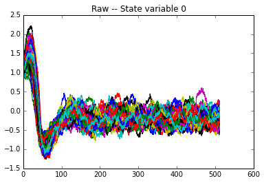

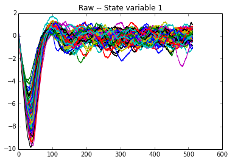

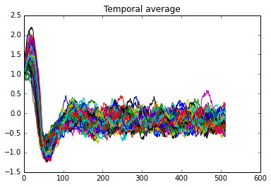

```python
#Make the lists numpy.arrays for easier use.
RAW = numpy.array(raw_data)
TAVG = numpy.array(tavg_data)

#Plot raw time series
figure(1)
plot(raw_time, RAW[:, 0, :, 0])
title("Raw -- State variable 0")

figure(2)
plot(raw_time, RAW[:, 1, :, 0])
title("Raw -- State variable 1")

#Plot temporally averaged time series
figure(3)
plot(tavg_time, TAVG[:, 0, :, 0])
title("Temporal average")

#Show them
show()
```

The large amplitude oscillations at the start are, of course, our usual large transient resulting from our being too lazy to properly set initial conditions. But after that we see a small amplitude noise driven exploration of the small piece of phase-space surrounding the fixed point produced by the default parameters for Generic2dOscillator.

## That's All Folks... so, what next?

That's all for this tutorial, the main new thing was a bit of discussion and an example of running a stochastic simulation.